# Phase 1 - Predicting Post-fight Winning Streaks of UFC Fighters

#### Group Name: 92

#### Name(s) & ID(s) of Group Members:

- Myeonghoon - s3774430
- Introduction
  - Dataset Source
  - Dataset Details
  - Dataset Variables
  - Response Variable
- Goals and Objectvies
- Data Cleaning and Preprocessing
- Data Exploration and Visualisation
- Summary and Conclusion
- References

## Introduction

### Dataset Source

The dataset used in this report was sourced from Kaggle at https://www.kaggle.com/rajeevw/ufcdata (Warrier, 2019). The dataset includes all events from the dawn of the Ultimate Fighting Championship (UFC) in 1993 to 21 March 2021.

### Dataset Details

Each row in the dataset represents a fight and contains both fighters' statistics leading up to the match. Fighters are labeled red and blue. Each fighter's statistics include average damage, inflicted and received (denoted by the prefix `'opp'`), in all of his previous fights; detailed fight records including winning and losing streaks; and such biometrics as height, reach and age. The overall structure of the dataset as it stands now is most appropriate for predictive modeling, but ill-fitted for plotting for insights. Hence we will modify the dataset to plot more meaningful plots.

```python
import warnings
warnings.filterwarnings('ignore')

import numpy as np
import pandas as pd

import matplotlib.pyplot as plt
import seaborn as sns
%matplotlib inline
%config InlineBackend.figure_format = 'retina'
plt.style.use('ggplot')

df = pd.read_csv('Phase1_Group92.csv')
pd.set_option('display.max_columns', None)
pd.set_option('precision', 3)
```

Let us first have a look at 10 randomly selected, transposed observations in the raw dataset.

```python
df.sample(n=10, random_state=999)
```

|  | R_fighter | B_fighter | Referee | date | location | Winner | title_bout | weight_class | B_avg_KD | B_avg_opp_KD | B_avg_SIG_STR_pct | B_avg_opp_SIG_STR_pct | B_avg_TD_pct | B_avg_opp_TD_pct | B_avg_SUB_ATT | B_avg_opp_SUB_ATT | B_avg_REV | B_avg_opp_REV | B_avg_SIG_STR_att | B_avg_SIG_STR_landed | B_avg_opp_SIG_STR_att | B_avg_opp_SIG_STR_landed | B_avg_TOTAL_STR_att | B_avg_TOTAL_STR_landed | B_avg_opp_TOTAL_STR_att | B_avg_opp_TOTAL_STR_landed | B_avg_TD_att | B_avg_TD_landed | B_avg_opp_TD_att | … |
| --- | --- | --- | --- | --- | --- | --- | --- | --- | --- | --- | --- | --- | --- | --- | --- | --- | --- | --- | --- | --- | --- | --- | --- | --- | --- | --- | --- | --- | --- | --- |
| 5670 | Yves Edwards | Rich Clementi | Larry Landless | 2003-02-28 | Atlantic City, New Jersey, USA | Red | False | Lightweight | NaN | NaN | NaN | NaN | NaN | NaN | NaN | NaN | NaN | NaN | NaN | NaN | NaN | NaN | NaN | NaN | NaN | NaN | NaN | NaN | NaN | … |
| 3604 | Mike Ricci | Myles Jury | John McCarthy | 2013-09-21 | Toronto, Ontario, Canada | Blue | False | Lightweight | 0.500 | 0.000 | 0.275 | 0.195 | 0.625 | 0.750 | 0.500 | 0.0 | 0.500 | 0.5 | 54.500 | 19.500 | 31.000 | 6.000 | 83.000 | 41.250 | 34.000 | 9.000 | 2.500 | 1.750 | 0.750 | … |
| 934 | Alex Oliveira | Mike Perry | Larry Downs | 2019-04-27 | Sunrise, Florida, USA | Blue | False | Welterweight | 0.078 | 0.195 | 0.522 | 0.569 | 0.759 | 0.070 | 0.000 | 0.5 | 0.000 | 0.5 | 62.906 | 31.324 | 73.133 | 34.465 | 64.066 | 32.480 | 76.242 | 37.574 | 1.812 | 1.188 | 1.180 | … |
| 1123 | Max Holloway | Brian Ortega | Yves Lavigne | 2018-12-08 | Toronto, Ontario, Canada | Red | True | Featherweight | 0.578 | 0.062 | 0.323 | 0.432 | 0.005 | 0.154 | 0.734 | 0.0 | 0.016 | 0.0 | 99.922 | 32.094 | 111.266 | 48.453 | 100.828 | 32.484 | 114.172 | 50.562 | 0.578 | 0.016 | 1.406 | … |
| 4567 | Jon Madsen | Gilbert Yvel | John McCarthy | 2010-10-23 | Anaheim, California, USA | Red | False | Heavyweight | 0.000 | 0.500 | 0.350 | 0.515 | 0.000 | 0.355 | 1.000 | 1.0 | 1.500 | 0.0 | 39.500 | 18.000 | 52.500 | 29.000 | 60.000 | 36.000 | 102.000 | 68.500 | 0.500 | 0.000 | 3.500 | … |
| 2209 | Sam Alvey | Kevin Casey | Yves Lavigne | 2016-08-27 | Vancouver, British Columbia, Canada | Red | False | Middleweight | 0.031 | 0.281 | 0.510 | 0.499 | 0.186 | 0.142 | 0.062 | 0.0 | 0.062 | 0.0 | 60.625 | 36.969 | 88.938 | 48.062 | 77.906 | 53.750 | 138.406 | 93.406 | 3.719 | 1.062 | 1.750 | … |
| 669 | Daniel Spitz | Tanner Boser | Gary Forman | 2019-10-18 | Boston, Massachusetts, USA | Blue | False | Heavyweight | NaN | NaN | NaN | NaN | NaN | NaN | NaN | NaN | NaN | NaN | NaN | NaN | NaN | NaN | NaN | NaN | NaN | NaN | NaN | NaN | NaN | … |
| 3390 | Carlos Condit | Tyron Woodley | Jacob Montalvo | 2014-03-15 | Dallas, Texas, USA | Blue | False | Welterweight | 1.250 | 0.000 | 0.647 | 0.260 | 0.000 | 0.000 | 0.000 | 0.0 | 0.000 | 0.0 | 46.000 | 29.750 | 60.750 | 23.000 | 67.750 | 51.500 | 75.750 | 36.500 | 0.000 | 0.000 | 4.500 | … |
| 3761 | Nate Diaz | Josh Thomson | Mike Beltran | 2013-04-20 | San Jose, California, USA | Blue | False | Lightweight | 0.250 | 0.750 | 0.593 | 0.497 | 0.745 | 0.165 | 0.000 | 1.0 | 0.000 | 0.0 | 32.500 | 19.250 | 22.000 | 13.500 | 56.000 | 41.750 | 36.750 | 27.000 | 2.500 | 1.750 | 1.250 | … |
| 5358 | Keith Jardine | Forrest Griffin | John McCarthy | 2006-12-30 | Las Vegas, Nevada, USA | Red | False | LightHeavyweight | 0.125 | 0.000 | 0.406 | 0.379 | 0.076 | 0.062 | 0.125 | 0.0 | 0.000 | 0.0 | 168.000 | 65.438 | 126.062 | 41.625 | 179.812 | 75.500 | 137.562 | 51.875 | 0.625 | 0.188 | 3.000 | … |

### Dataset Variables

The features in the dataset are set out in the table below. All features with `avg` in their names store compiled data up to the current fight, which corresponds to each row. For example, `'B_avg_SIG_STR_pct'` of a particular observation has the mean of the *blue* fighter's significant strikes out of total strikes (in fraction) in all of his/her fights prior to the current fight. For all this type of features, there are `_opp_` counterparts. From `'B_avg_opp_SIG_STR_pct'` column, we can find out the same information against the blue fighter by all the fighters he/she has previously faced. The `_opp_` counterparts are intentionally excluded from the table below for conciseness. Since each observation contains two fighters' statistics, assume that for every feature of `B_fighter`, there is an equivalent of `R_fighter`, which is not also included in the table below for word economy.

Only some of the features will be utilised in Phase 1 while others will be used in Phase 2. With this in mind, let us explore the dataset features.

**Side Notes**

Significant strikes are defined as all strikes at distance and power strikes in the clinch and on the ground. (DraftKings, n.d.)

```python
from tabulate import tabulate

table = [['Name', 'Data Type', 'Units', 'Description'],
         ['','','',''],
         ['B_Stance', 'Nominal Categorical', 'NA', "The fighter's stance"],
         ['B_Height_cms', 'Continuous Numerical', 'cm', 'The height of the fighter'],
         ['B_Reach_cms', 'Continuous Numerical', 'cm', 'The reach of the fighter'],
         ['B_age', 'Discrete Numerical', 'NA', 'The age of the fighter'],
         ['Winner', 'Nominal Categorical', 'NA', 'The winner of a fight'],
         ['title_bout', 'Binary', 'NA', 'Whether the fight is a title-bout or not'],
         ['weight_class', 'Nominal Categorical', 'NA', 'The weight division to which the fighter belongs'],
         ['B_avg_KD', 'Continuous Numerical', 'NA', 'The average knockdowns'],
         ['B_avg_SIG_STR_pct', 'Continuous Numerical', 'NA', 'The average significant strikes out of total strikes'],
         ['B_avg_TD_pct', 'Continuous Numerical', 'NA', 'The average successful takedowns out of total attempts'],
         ['B_avg_SUB_ATT', 'Continuous Numerical', 'NA', 'The average submission attempts'],
         ['B_avg_REV', 'Continuous Numerical', 'NA', 'The average reversals (on the ground)'],
         ['B_avg_SIG_STR_att', 'Continuous Numerical', 'NA', 'The average significant strikes attmpted'],
         ['B_avg_SIG_STR_landed', 'Continuous Numerical', 'NA', 'The average significant strikes landed'],
         ['B_avg_TOTAL_STR_att', 'Continuous Numerical', 'NA', 'The average total strikes attempted'],
         ['B_avg_TOTAL_STR_landed', 'Continuous Numerical', 'NA', 'The average total strikes landed'],
         ['B_avg_TD_att', 'Continuous Numerical', 'NA', 'The average takedowns attempted'],
         ['B_avg_TD_landed', 'Continuous Numerical', 'NA', 'The average takedowns landed'],
         ['B_avg_HEAD_att', 'Continuous Numerical', 'NA', 'The average strikes to the head attempted'],
         ['B_avg_HEAD_landed', 'Continuous Numerical', 'NA', 'The average strikes to the head landed'],
         ['B_avg_BODY_att', 'Continuous Numerical', 'NA', 'The average strikes to the body attempted'],
         ['B_avg_BODY_landed', 'Continuous Numerical', 'NA', 'The average strikes to the body landed'],
         ['B_avg_LEG_att', 'Continuous Numerical', 'NA', 'The average strikes to the leg attempted'],
         ['B_avg_LEG_landed', 'Continuous Numerical', 'NA', 'The average strikes to the leg landed'],
         ['B_avg_DISTANCE_att', 'Continuous Numerical', 'NA', 'The average strikes from a distance attempted'],
         ['B_avg_DISTANCE_landed', 'Continuous Numerical', 'NA', 'The average strikes from a distance landed'],
         ['B_avg_CLINCH_att', 'Continuous Numerical', 'NA', 'The average strikes from a clinch attempted'],
         ['B_avg_CLINCH_landed', 'Continuous Numerical', 'NA', 'The average strikes from a clinch landed'],
         ['B_avg_GROUND_att', 'Continuous Numerical', 'NA', 'The average strikes while on ground attempted'],
         ['B_avg_GROUND_landed', 'Continuous Numerical', 'NA', 'The average strikes while on ground landed'],
         ['B_avg_CTRL_time(seconds)', 'Continuous Numerical', 'seconds', 'The average duration on the offensive'],
         ['B_total_rounds_fought', 'Discrete Numerical', 'NA', 'The total rounds the fighter has fought'],
         ['B_total_title_bouts', 'Discrete Numerical', 'NA', 'The total title bouts the fighter has fought'],
         ['B_current_win_streak', 'Discrete Numerical', 'NA', 'The current winning streak of the fighter'],
         ['B_current_lose_streak', 'Discrete Numerical', 'NA', 'The current losing streak of the fighter'],
         ['B_longest_win_streak', 'Discrete Numerical', 'NA', 'The longest winning streak of the fighter'],
         ['B_wins', 'Discrete Numerical', 'NA', "The number of wins in the fighter's UFC career"],
         ['B_losses', 'Discrete Numerical', 'NA', "The number of losses in the fighter's UFC career"],
         ['B_draw', 'Discrete Numerical', 'NA', "The number of draws in the fighter's UFC career"],
         ['B_win_by_Decision_Majority', 'Discrete Numerical', 'NA', 'the number of wins by majority judges decision'],
         ['B_win_by_Decision_Split', 'Discrete Numerical', 'NA', 'the number of wins by split judges decision'],
         ['B_win_by_Decision_Unanimous', 'Discrete Numerical', 'NA', 'the number of wins by unanimous judges decision'],
         ['B_win_by_KO/TKO', 'Discrete Numerical', 'NA', 'the number of wins by knockout'],
         ['B_win_by_Submission', 'Discrete Numerical', 'NA', 'the number of wins by submission'],
         ['B_win_by_TKO_Doctor_Stoppage', 'Discrete Numerical', 'NA', 'the number of wins by doctor stoppage']]

print(tabulate(table, headers='firstrow', tablefmt='plain'))
```

```
Name                          Data Type             Units    Description

B_Stance                      Nominal Categorical   NA       The fighter's stance
B_Height_cms                  Continuous Numerical  cm       The height of the fighter
B_Reach_cms                   Continuous Numerical  cm       The reach of the fighter
B_age                         Discrete Numerical    NA       The age of the fighter
Winner                        Nominal Categorical   NA       The winner of a fight
title_bout                    Binary                NA       Whether the fight is a title-bout or not
weight_class                  Nominal Categorical   NA       The weight division to which the fighter belongs
B_avg_KD                      Continuous Numerical  NA       The average knockdowns
B_avg_SIG_STR_pct             Continuous Numerical  NA       The average significant strikes out of total strikes
B_avg_TD_pct                  Continuous Numerical  NA       The average successful takedowns out of total attempts
B_avg_SUB_ATT                 Continuous Numerical  NA       The average submission attempts
B_avg_REV                     Continuous Numerical  NA       The average reversals (on the ground)
B_avg_SIG_STR_att             Continuous Numerical  NA       The average significant strikes attmpted
B_avg_SIG_STR_landed          Continuous Numerical  NA       The average significant strikes landed
B_avg_TOTAL_STR_att           Continuous Numerical  NA       The average total strikes attempted
B_avg_TOTAL_STR_landed        Continuous Numerical  NA       The average total strikes landed
B_avg_TD_att                  Continuous Numerical  NA       The average takedowns attempted
B_avg_TD_landed               Continuous Numerical  NA       The average takedowns landed
B_avg_HEAD_att                Continuous Numerical  NA       The average strikes to the head attempted
B_avg_HEAD_landed             Continuous Numerical  NA       The average strikes to the head landed
B_avg_BODY_att                Continuous Numerical  NA       The average strikes to the body attempted
B_avg_BODY_landed             Continuous Numerical  NA       The average strikes to the body landed
B_avg_LEG_att                 Continuous Numerical  NA       The average strikes to the leg attempted
B_avg_LEG_landed              Continuous Numerical  NA       The average strikes to the leg landed
B_avg_DISTANCE_att            Continuous Numerical  NA       The average strikes from a distance attempted
B_avg_DISTANCE_landed         Continuous Numerical  NA       The average strikes from a distance landed
B_avg_CLINCH_att              Continuous Numerical  NA       The average strikes from a clinch attempted
B_avg_CLINCH_landed           Continuous Numerical  NA       The average strikes from a clinch landed
B_avg_GROUND_att              Continuous Numerical  NA       The average strikes while on ground attempted
B_avg_GROUND_landed           Continuous Numerical  NA       The average strikes while on ground landed
B_avg_CTRL_time(seconds)      Continuous Numerical  seconds  The average duration on the offensive
B_total_rounds_fought         Discrete Numerical    NA       The total rounds the fighter has fought
B_total_title_bouts           Discrete Numerical    NA       The total title bouts the fighter has fought
B_current_win_streak          Discrete Numerical    NA       The current winning streak of the fighter
B_current_lose_streak         Discrete Numerical    NA       The current losing streak of the fighter
B_longest_win_streak          Discrete Numerical    NA       The longest winning streak of the fighter
B_wins                        Discrete Numerical    NA       The number of wins in the fighter's UFC career
B_losses                      Discrete Numerical    NA       The number of losses in the fighter's UFC career
B_draw                        Discrete Numerical    NA       The number of draws in the fighter's UFC career
B_win_by_Decision_Majority    Discrete Numerical    NA       the number of wins by majority judges decision
B_win_by_Decision_Split       Discrete Numerical    NA       the number of wins by split judges decision
B_win_by_Decision_Unanimous   Discrete Numerical    NA       the number of wins by unanimous judges decision
B_win_by_KO/TKO               Discrete Numerical    NA       the number of wins by knockout
B_win_by_Submission           Discrete Numerical    NA       the number of wins by submission
B_win_by_TKO_Doctor_Stoppage  Discrete Numerical    NA       the number of wins by doctor stoppage
```

### Response Variable

When it comes to sports, predicting the winner is generally of most interest among regular viewers, ardent sports fans and sports data analysts. However, since our target feature should be numerical, not categorical, we have decided to create a derived feature `R_post_fight_win_streak` from existing `R_current_win_streak` and `Winner`.

`R_current_win_streak` does not accurately reflect the winning streak in all the previous fights before the current fight, but it holds the same value as `R_longest_win_streak`. First, we will rectify the values of the former feature. Next, the result of the current fight, represented in `Winner`, will be factored in so that the target feature is set to 0 or `R_current_win_streak` $+$ 1, depending on the outcome of a fight.

## Goals and Objectives

As the abbreviation MMA (Mixed Martial Arts) denotes, fighting has mostly been considered more of arts than science. This perception was turned on its head after the advent of Royce Gracie at UFC 1. He had brought in an algorithmic system of fighting style and established himself as a champion until other fighters caught up to his fight algorithms, namely Brazilian Jiu-jitsu. Since then, a great many of good fighters have taken a 'if-else/while' algorithmic approach, rendering data on fights ripe for machine learning analytics. A lot is at stake when fighters enter the octagon. One brutal fight can be the harbinger of the end of a fighter's career.

There is enough initiative to ascertain what attributes highly correlate with fighters on a winning streak. During the data exploration and visualisation in Phase 1, we will try to gain insight into existing correlations between attributes (descriptive features) and winners. First, we will look at the number of fights across weight divisions to get a general idea of fight distributions. The attributes associated with winners can be categorized as fixed and improvable; As an analysis of a fixed attribute, we aim to find out how many winners have a longer reach than opponents. We could then analyze the relationship between the winning fighter's stance, somewhat fixed yet improvable through training, and the number of his/her consecutive wins. We will also examine data on improvable attributes among winning fighters; Improvable factors include striking, wrestling, submission, etc.

The ultimate objective of this project is to predict the number of consecutive wins post-fight based on cumulative data available prior to the fight. We aim to produce a model with a high R$^2_{adj}$ so that we gain deeper insight into what attributes most correlate with winning streaks. If it proves futile to improve the model fit of our multiple regression, we shall endeavour to predict the values of our response feature with the help of Neural Networks (NN) models.

## Data Cleaning and Preprocessing

### Overview

In this section, we will take prerequisite steps to cleaning our data for predictive modelling. The preprocessing steps are as follows:

1. Check whether there is any oddity in the values of features.
2. Change names of columns and values as required
3. Address irrelevant features.
4. Check for rows with missing or unusual values and drop them.
5. Create another version of `df` without single outliers.

To ensure our dataset is free of columns with one constant values, let us run a check-up.

```python
df.nunique()[df.nunique() == 1]
```

```
B_draw    1
R_draw    1
dtype: int64
```

Let us find out what constant value each of the columns holds.

```python
print(f"B_draw's unique value is {df['B_draw'].unique()}")
print(f"R_draw's unique value is {df['R_draw'].unique()}")
```

```
B_draw's unique value is [0]
R_draw's unique value is [0]
```

It is hardly believable no fight has resulted in a draw in the entire history of UFC. Let us double-check.

```python
df['Winner'].value_counts()
```

```
Red     3979
Blue    1923
Draw     110
Name: Winner, dtype: int64
```

We can see that there have been draws, but the columns do not contain this information. We shall update their values below while we adjust values of other columns.

We will check whether our features `_current_win_streak` (throughout the report, the absence of the prefix *R* or *B* at the beginning of a column's name refers to both fighters' features), store appropriate values in line with the fight history. We will do so by checking fight records of the legendary fighter, Anderson Silva.

```python
df.loc[(df['R_fighter']== 'Anderson Silva') |(df['B_fighter']== 'Anderson Silva'), ['date','Winner', 'B_fighter', 'B_draw', 'B_current_win_streak', 'R_fighter', 'R_draw', 'R_current_win_streak']][11:1:-1]
```

|  | date | Winner | B_fighter | B_draw | B_current_win_streak | R_fighter | R_draw | R_current_win_streak |
| --- | --- | --- | --- | --- | --- | --- | --- | --- |
| 4333 | 2011-08-27 | Red | Yushin Okami | 0 | 4 | Anderson Silva | 0 | 13 |
| 4028 | 2012-07-07 | Red | Chael Sonnen | 0 | 0 | Anderson Silva | 0 | 14 |
| 3943 | 2012-10-13 | Red | Stephan Bonnar | 0 | 0 | Anderson Silva | 0 | 15 |
| 3691 | 2013-07-06 | Blue | Chris Weidman | 0 | 5 | Anderson Silva | 0 | 16 |
| 3492 | 2013-12-28 | Red | Anderson Silva | 0 | 16 | Chris Weidman | 0 | 6 |
| 2944 | 2015-01-31 | Draw | Nick Diaz | 0 | 2 | Anderson Silva | 0 | 16 |
| 2438 | 2016-02-27 | Blue | Michael Bisping | 0 | 4 | Anderson Silva | 0 | 16 |
| 2282 | 2016-07-09 | Red | Anderson Silva | 0 | 16 | Daniel Cormier | 0 | 4 |
| 1978 | 2017-02-11 | Red | Derek Brunson | 0 | 2 | Anderson Silva | 0 | 16 |
| 1057 | 2019-02-09 | Red | Anderson Silva | 0 | 16 | Israel Adesanya | 0 | 4 |

As we can see above, we do not see the expected value of 0 after Silva's defeat to Weidman (index 3492); Also his R_draw is 0 (index 2438) after his draw with Diaz (index 2944). Before we go ahead and fix the column, let us check whether the closely related column `_current_lose_streak` also exhibits the same error.

```python
df[(df['R_fighter']== 'Anderson Silva') |(df['B_fighter']== 'Anderson Silva')][['date','Winner', 'B_fighter', 'B_draw', 'B_current_lose_streak', 'R_fighter', 'R_draw', 'R_current_lose_streak']][11:1:-1]
```

|  | date | Winner | B_fighter | B_draw | B_current_lose_streak | R_fighter | R_draw | R_current_lose_streak |
| --- | --- | --- | --- | --- | --- | --- | --- | --- |
| 4333 | 2011-08-27 | Red | Yushin Okami | 0 | 0 | Anderson Silva | 0 | 0 |
| 4028 | 2012-07-07 | Red | Chael Sonnen | 0 | 1 | Anderson Silva | 0 | 0 |
| 3943 | 2012-10-13 | Red | Stephan Bonnar | 0 | 1 | Anderson Silva | 0 | 0 |
| 3691 | 2013-07-06 | Blue | Chris Weidman | 0 | 0 | Anderson Silva | 0 | 0 |
| 3492 | 2013-12-28 | Red | Anderson Silva | 0 | 0 | Chris Weidman | 0 | 0 |
| 2944 | 2015-01-31 | Draw | Nick Diaz | 0 | 0 | Anderson Silva | 0 | 0 |
| 2438 | 2016-02-27 | Blue | Michael Bisping | 0 | 0 | Anderson Silva | 0 | 0 |
| 2282 | 2016-07-09 | Red | Anderson Silva | 0 | 0 | Daniel Cormier | 0 | 0 |
| 1978 | 2017-02-11 | Red | Derek Brunson | 0 | 0 | Anderson Silva | 0 | 0 |
| 1057 | 2019-02-09 | Red | Anderson Silva | 0 | 0 | Israel Adesanya | 0 | 0 |

Despite Silva's consecutive losses against Weidman, we do not see his downfall above. We shall now adjust the dataset so that `_current_win_streak`, `_current_lose_streak` and `_draw` contain accurate information. We will then create our target feature `R_post_fight_win_streak` in the process below. Also, we will create `B_post_fight_win_streak`, `B_post_fight_lose_streak` and `R_post_fight_lose_streak` for plotting purposes only to drop them at the end.

```python
# Make sure there's no space surroudning the names
df['R_fighter'] = df['R_fighter'].str.strip()
df['B_fighter'] = df['B_fighter'].str.strip()

r_fighters = pd.Index(df['R_fighter'])
b_fighters = pd.Index(df['B_fighter'])

fighters = list(r_fighters | b_fighters)

# Dictionary to hold fighters' names ,winning streaks and draws
win_streaks = {fighter: 0 for fighter in fighters}
lose_streaks = {fighter: 0 for fighter in fighters}
draws = {fighter: 0 for fighter in fighters}

# Traverse from the past to the present
df = df.iloc[::-1]
for index, row in df.iterrows():
    # Update _draw, _current_win_streak and _current_lose_streak so that their values are based on the fight records prior to the current fight
    df.at[index, 'B_draw'] = draws[row['B_fighter']]
    df.at[index, 'R_draw'] = draws[row['R_fighter']]
    df.at[index, 'B_current_win_streak'] = win_streaks[row['B_fighter']]
    df.at[index, 'R_current_win_streak'] = win_streaks[row['R_fighter']]
    df.at[index, 'B_current_lose_streak'] = lose_streaks[row['B_fighter']]
    df.at[index, 'R_current_lose_streak'] = lose_streaks[row['R_fighter']]

    if row['Winner'] == 'Red':
        win_streaks[row['R_fighter']] += 1
        win_streaks[row['B_fighter']] = 0
        lose_streaks[row['B_fighter']] += 1
        lose_streaks[row['R_fighter']] = 0
    elif row['Winner'] == 'Blue':
        win_streaks[row['B_fighter']] += 1
        win_streaks[row['R_fighter']] = 0
        lose_streaks[row['R_fighter']] += 1
        lose_streaks[row['B_fighter']] = 0
    else: # Draw
        win_streaks[row['R_fighter']] = 0
        win_streaks[row['B_fighter']] = 0
        lose_streaks[row['B_fighter']] = 0
        lose_streaks[row['R_fighter']] = 0
        # If this fight ends up in a draw, store the result in draws
        draws[row['B_fighter']] += 1
        draws[row['R_fighter']] += 1

    df.at[index, 'R_post_fight_win_streak'] = win_streaks[row['R_fighter']]
    df.at[index, 'B_post_fight_win_streak'] = win_streaks[row['B_fighter']]
    df.at[index, 'R_post_fight_lose_streak'] = lose_streaks[row['R_fighter']]
    df.at[index, 'B_post_fight_lose_streak'] = lose_streaks[row['B_fighter']]

# Set df in the original order
df = df.iloc[::-1]

df[(df['R_fighter']== 'Anderson Silva') |(df['B_fighter']== 'Anderson Silva')][['date','Winner', 'B_fighter', 'B_draw', 'B_current_win_streak', 'R_fighter', 'R_draw', 'R_current_win_streak', 'R_post_fight_win_streak']][11:1:-1]
```

|  | date | Winner | B_fighter | B_draw | B_current_win_streak | R_fighter | R_draw | R_current_win_streak | R_post_fight_win_streak |
| --- | --- | --- | --- | --- | --- | --- | --- | --- | --- |
| 4333 | 2011-08-27 | Red | Yushin Okami | 0 | 3 | Anderson Silva | 0 | 13 | 14.0 |
| 4028 | 2012-07-07 | Red | Chael Sonnen | 0 | 2 | Anderson Silva | 0 | 14 | 15.0 |
| 3943 | 2012-10-13 | Red | Stephan Bonnar | 0 | 3 | Anderson Silva | 0 | 15 | 16.0 |
| 3691 | 2013-07-06 | Blue | Chris Weidman | 0 | 5 | Anderson Silva | 0 | 16 | 0.0 |
| 3492 | 2013-12-28 | Red | Anderson Silva | 0 | 0 | Chris Weidman | 0 | 6 | 7.0 |
| 2944 | 2015-01-31 | Draw | Nick Diaz | 0 | 0 | Anderson Silva | 0 | 0 | 0.0 |
| 2438 | 2016-02-27 | Blue | Michael Bisping | 0 | 2 | Anderson Silva | 1 | 0 | 0.0 |
| 2282 | 2016-07-09 | Red | Anderson Silva | 1 | 0 | Daniel Cormier | 0 | 2 | 3.0 |
| 1978 | 2017-02-11 | Red | Derek Brunson | 0 | 0 | Anderson Silva | 1 | 0 | 1.0 |
| 1057 | 2019-02-09 | Red | Anderson Silva | 1 | 1 | Israel Adesanya | 0 | 4 | 5.0 |

```python
print(f"B_draw's unique value is {df['B_draw'].unique()}")
print(f"R_draw's unique value is {df['R_draw'].unique()}")
```

```
B_draw's unique value is [0 1 2 3]
R_draw's unique value is [0 1 2]
```

Now that we have `_current_win_streak`, `_current_lose_streak` and `_draw` adjusted as needed, we will start cleaning up our dataset. First, we will make all column names lowercase and remove potential whitespace for consistency. We will also rename some columns as required for Phase 2.

Next, since fighters' names themselves do not help predict their winning streaks, we will create a MultiIndex using `b_fighter` and `r_fighter` columns.

```python
df.columns = df.columns.str.lower().str.strip()
df.columns = df.columns.str.replace('\(seconds\)','_seconds' )
df.columns = df.columns.str.replace('ko/tko', 'ko_tko' )
df.set_index(['r_fighter', 'b_fighter'], inplace=True)
df.sample(n=5, random_state=999)
```

| r_fighter | b_fighter | referee | date | location | winner | title_bout | weight_class | b_avg_kd | b_avg_opp_kd | b_avg_sig_str_pct | b_avg_opp_sig_str_pct | b_avg_td_pct | b_avg_opp_td_pct | b_avg_sub_att | b_avg_opp_sub_att | b_avg_rev | b_avg_opp_rev | b_avg_sig_str_att | b_avg_sig_str_landed | b_avg_opp_sig_str_att | b_avg_opp_sig_str_landed | b_avg_total_str_att | b_avg_total_str_landed | b_avg_opp_total_str_att | b_avg_opp_total_str_landed | b_avg_td_att | b_avg_td_landed | b_avg_opp_td_att | b_avg_opp_td_landed | … |
| --- | --- | --- | --- | --- | --- | --- | --- | --- | --- | --- | --- | --- | --- | --- | --- | --- | --- | --- | --- | --- | --- | --- | --- | --- | --- | --- | --- | --- | --- | --- |
| Yves Edwards | Rich Clementi | Larry Landless | 2003-02-28 | Atlantic City, New Jersey, USA | Red | False | Lightweight | NaN | NaN | NaN | NaN | NaN | NaN | NaN | NaN | NaN | NaN | NaN | NaN | NaN | NaN | NaN | NaN | NaN | NaN | NaN | NaN | NaN | NaN | … |
| Mike Ricci | Myles Jury | John McCarthy | 2013-09-21 | Toronto, Ontario, Canada | Blue | False | Lightweight | 0.500 | 0.000 | 0.275 | 0.195 | 0.625 | 0.750 | 0.500 | 0.0 | 0.500 | 0.5 | 54.500 | 19.500 | 31.000 | 6.000 | 83.000 | 41.250 | 34.000 | 9.000 | 2.500 | 1.750 | 0.750 | 0.750 | … |
| Alex Oliveira | Mike Perry | Larry Downs | 2019-04-27 | Sunrise, Florida, USA | Blue | False | Welterweight | 0.078 | 0.195 | 0.522 | 0.569 | 0.759 | 0.070 | 0.000 | 0.5 | 0.000 | 0.5 | 62.906 | 31.324 | 73.133 | 34.465 | 64.066 | 32.480 | 76.242 | 37.574 | 1.812 | 1.188 | 1.180 | 0.219 | … |
| Max Holloway | Brian Ortega | Yves Lavigne | 2018-12-08 | Toronto, Ontario, Canada | Red | True | Featherweight | 0.578 | 0.062 | 0.323 | 0.432 | 0.005 | 0.154 | 0.734 | 0.0 | 0.016 | 0.0 | 99.922 | 32.094 | 111.266 | 48.453 | 100.828 | 32.484 | 114.172 | 50.562 | 0.578 | 0.016 | 1.406 | 0.406 | … |
| Jon Madsen | Gilbert Yvel | John McCarthy | 2010-10-23 | Anaheim, California, USA | Red | False | Heavyweight | 0.000 | 0.500 | 0.350 | 0.515 | 0.000 | 0.355 | 1.000 | 1.0 | 1.500 | 0.0 | 39.500 | 18.000 | 52.500 | 29.000 | 60.000 | 36.000 | 102.000 | 68.500 | 0.500 | 0.000 | 3.500 | 2.500 | … |

Since we can deduce who has won the fight based on the values of `_post_fight_win_streak` and `_current_win_streak`, `winner` column is redundant. However, we will keep this column intact for ease of plotting the dataset later on. It is only after that we will drop the column. On the other hand, `referee`, `date`, `location` features are not necessary for both plotting and predictive modelling. Since `_weight_lbs` columns refer to the fighter's identical weigh-in weights, they will only serve as noises. We shall now drop those columns.

```python
df.drop(columns=['referee', 'date', 'location', 'r_weight_lbs', 'b_weight_lbs'], inplace=True)
```

Let us now turn our attention to missing values in observations and drop the rows with any missing value.

```python
df.isna().sum()
```

```
winner                         0
title_bout                     0
weight_class                   0
b_avg_kd                    1427
b_avg_opp_kd                1427
                            ...
r_age                         63
r_post_fight_win_streak        0
b_post_fight_win_streak        0
r_post_fight_lose_streak       0
b_post_fight_lose_streak       0
Length: 141, dtype: int64
```

```python
df.dropna(inplace=True)
```

### Summary Statistics

```python
from IPython.display import display, HTML
display(HTML('<b>Table 1: Summary of numerical features</b>'))
df.describe(include=['int64', 'float64'])
```

**Table 1: Summary of numerical features**

|  | b_avg_kd | b_avg_opp_kd | b_avg_sig_str_pct | b_avg_opp_sig_str_pct | b_avg_td_pct | b_avg_opp_td_pct | b_avg_sub_att | b_avg_opp_sub_att | b_avg_rev | b_avg_opp_rev | b_avg_sig_str_att | b_avg_sig_str_landed | b_avg_opp_sig_str_att | b_avg_opp_sig_str_landed | b_avg_total_str_att | b_avg_total_str_landed | b_avg_opp_total_str_att | b_avg_opp_total_str_landed | b_avg_td_att | b_avg_td_landed | b_avg_opp_td_att | b_avg_opp_td_landed | b_avg_head_att | b_avg_head_landed | b_avg_opp_head_att | b_avg_opp_head_landed | b_avg_body_att | b_avg_body_landed | b_avg_opp_body_att | … |
| --- | --- | --- | --- | --- | --- | --- | --- | --- | --- | --- | --- | --- | --- | --- | --- | --- | --- | --- | --- | --- | --- | --- | --- | --- | --- | --- | --- | --- | --- | --- |
| count | 3914.000 | 3914.000 | 3914.000 | 3914.000 | 3914.000 | 3914.000 | 3914.000 | 3914.000 | 3914.000 | 3914.000 | 3914.000 | 3914.000 | 3914.000 | 3914.000 | 3914.000 | 3914.000 | 3914.000 | 3914.000 | 3914.000 | 3914.000 | 3914.000 | 3914.000 | 3914.000 | 3914.000 | 3914.000 | 3914.000 | 3914.000 | 3914.000 | 3914.000 | … |
| mean | 0.264 | 0.172 | 0.455 | 0.428 | 0.295 | 0.257 | 0.468 | 0.378 | 0.154 | 0.136 | 81.097 | 35.508 | 76.588 | 32.149 | 102.551 | 54.505 | 95.513 | 48.942 | 2.820 | 1.158 | 2.909 | 1.052 | 63.784 | 22.823 | 59.753 | 19.994 | 10.331 | 7.114 | 9.842 | … |
| std | 0.383 | 0.307 | 0.120 | 0.122 | 0.264 | 0.250 | 0.698 | 0.597 | 0.328 | 0.305 | 50.853 | 21.912 | 49.712 | 21.274 | 56.624 | 31.087 | 54.247 | 28.972 | 2.821 | 1.353 | 2.698 | 1.203 | 41.924 | 15.296 | 40.566 | 14.545 | 8.460 | 5.979 | 7.890 | … |
| min | 0.000 | 0.000 | 0.000 | 0.000 | 0.000 | 0.000 | 0.000 | 0.000 | 0.000 | 0.000 | 0.000 | 0.000 | 0.500 | 0.000 | 0.000 | 0.000 | 0.500 | 0.000 | 0.000 | 0.000 | 0.000 | 0.000 | 0.000 | 0.000 | 0.000 | 0.000 | 0.000 | 0.000 | 0.000 | … |
| 25% | 0.000 | 0.000 | 0.380 | 0.350 | 0.052 | 0.041 | 0.000 | 0.000 | 0.000 | 0.000 | 43.262 | 19.233 | 40.500 | 16.939 | 61.055 | 31.602 | 56.250 | 28.250 | 0.750 | 0.125 | 1.000 | 0.141 | 33.250 | 11.903 | 30.625 | 9.750 | 4.234 | 2.899 | 4.000 | … |
| 50% | 0.062 | 0.000 | 0.450 | 0.421 | 0.250 | 0.197 | 0.172 | 0.086 | 0.000 | 0.000 | 71.671 | 32.000 | 68.000 | 28.250 | 95.000 | 50.382 | 88.500 | 44.793 | 2.000 | 0.750 | 2.188 | 0.715 | 55.624 | 20.000 | 52.209 | 16.905 | 8.172 | 5.565 | 8.000 | … |
| 75% | 0.500 | 0.250 | 0.526 | 0.500 | 0.500 | 0.398 | 0.695 | 0.500 | 0.129 | 0.125 | 109.410 | 48.000 | 102.500 | 42.750 | 136.212 | 72.000 | 127.499 | 65.211 | 4.011 | 1.625 | 4.000 | 1.500 | 84.500 | 30.152 | 79.679 | 26.935 | 14.188 | 9.750 | 13.474 | … |
| max | 5.000 | 3.000 | 1.000 | 1.000 | 1.000 | 1.000 | 8.000 | 7.000 | 3.000 | 3.000 | 456.000 | 186.000 | 403.000 | 202.000 | 524.000 | 242.000 | 433.000 | 232.000 | 19.000 | 10.969 | 20.000 | 11.500 | 397.000 | 138.000 | 373.000 | 126.000 | 71.000 | 64.000 | 71.000 | … |

```python
display(HTML('<b>Table 2: Summary of categorical features</b>'))
df.describe(include='object').T
```

**Table 2: Summary of categorical features**

|  | count | unique | top | freq |
| --- | --- | --- | --- | --- |
| winner | 3914 | 3 | Red | 2411 |
| weight_class | 3914 | 13 | Lightweight | 735 |
| b_stance | 3914 | 4 | Orthodox | 2951 |
| r_stance | 3914 | 4 | Orthodox | 2947 |

According to the statistics summaries above, `_total_time_fought_seconds`'s maximum value goes only up to 1500 seconds, which equals five 5-minute rounds. Worse yet, its definition from the source is ambiguous. The most likely interpretation is that this column is concerned with the current fight's result. As we are only interested in the cumulative data prior to the current fight, we shall drop the columns, for `_total_rounds_fought` can be substituted as a measure for longevity of a fighter's career.

In keeping with the best practice, we will move the target feature `r_post_fight_win_streak` to the end of the columns.

```python
df.drop(columns=['r_total_time_fought_seconds', 'b_total_time_fought_seconds'], inplace=True)

df = df[[c for c in df.columns if c != 'r_post_fight_win_streak'] + ['r_post_fight_win_streak']]
df.sample(n=10, random_state=999)
```

| r_fighter | b_fighter | winner | title_bout | weight_class | b_avg_kd | b_avg_opp_kd | b_avg_sig_str_pct | b_avg_opp_sig_str_pct | b_avg_td_pct | b_avg_opp_td_pct | b_avg_sub_att | b_avg_opp_sub_att | b_avg_rev | b_avg_opp_rev | b_avg_sig_str_att | b_avg_sig_str_landed | b_avg_opp_sig_str_att | b_avg_opp_sig_str_landed | b_avg_total_str_att | b_avg_total_str_landed | b_avg_opp_total_str_att | b_avg_opp_total_str_landed | b_avg_td_att | b_avg_td_landed | b_avg_opp_td_att | b_avg_opp_td_landed | b_avg_head_att | b_avg_head_landed | b_avg_opp_head_att | … |
| --- | --- | --- | --- | --- | --- | --- | --- | --- | --- | --- | --- | --- | --- | --- | --- | --- | --- | --- | --- | --- | --- | --- | --- | --- | --- | --- | --- | --- | --- | --- |
| Mike Guymon | Daniel Roberts | Blue | False | Welterweight | 0.000 | 0.000 | 0.260 | 0.525 | 0.830 | 1.000 | 1.500 | 0.000 | 0.500 | 0.000e+00 | 30.500 | 6.000 | 38.500 | 13.500 | 63.000 | 33.000 | 54.000 | 27.500 | 5.000 | 3.500 | 1.000 | 1.000 | 29.500 | 5.500 | 28.000 | … |
| Daniel Roberts | Claude Patrick | Blue | False | Welterweight | 0.000 | 0.000 | 0.645 | 0.710 | 0.550 | 0.000 | 1.000 | 0.000 | 0.000 | 0.000e+00 | 29.000 | 18.000 | 16.500 | 8.500 | 57.500 | 43.500 | 43.000 | 31.500 | 3.500 | 2.000 | 1.500 | 0.000 | 24.000 | 14.000 | 7.500 | … |
| Ryan Bader | Carmelo Marrero | Red | False | LightHeavyweight | 0.000 | 0.500 | 0.323 | 0.495 | 0.150 | 0.250 | 0.000 | 1.750 | 0.000 | 0.000e+00 | 11.750 | 4.750 | 28.500 | 14.500 | 27.250 | 19.500 | 52.750 | 37.750 | 4.750 | 1.500 | 0.750 | 0.250 | 8.000 | 1.750 | 19.500 | … |
| Kyung Ho Kang | Guido Cannetti | Red | False | Bantamweight | 0.000 | 0.500 | 0.545 | 0.420 | 0.535 | 0.030 | 0.000 | 0.500 | 0.000 | 0.000e+00 | 62.000 | 33.500 | 50.500 | 22.500 | 70.500 | 41.500 | 77.000 | 47.000 | 4.500 | 2.500 | 7.500 | 0.500 | 37.500 | 14.000 | 36.000 | … |
| George Sotiropoulos | Joe Lauzon | Red | False | Lightweight | 0.008 | 0.000 | 0.554 | 0.242 | 0.591 | 0.141 | 1.750 | 0.000 | 0.133 | 1.406e-01 | 40.406 | 19.148 | 80.172 | 28.156 | 46.391 | 24.312 | 88.625 | 36.016 | 6.039 | 2.422 | 0.250 | 0.188 | 39.398 | 18.172 | 67.062 | … |
| Ion Cutelaba | Magomed Ankalaev | Blue | False | LightHeavyweight | 0.875 | 0.000 | 0.566 | 0.269 | 0.247 | 0.035 | 0.000 | 0.125 | 0.250 | 0.000e+00 | 65.625 | 38.375 | 37.500 | 11.375 | 107.750 | 74.625 | 46.250 | 19.125 | 2.250 | 0.750 | 3.125 | 0.250 | 48.125 | 25.250 | 27.375 | … |
| Dennis Bermudez | Jeremy Stephens | Blue | False | Featherweight | 0.064 | 0.016 | 0.502 | 0.469 | 0.209 | 0.146 | 0.039 | 2.034 | 0.004 | 4.387e-05 | 115.827 | 47.654 | 111.018 | 47.740 | 124.505 | 55.262 | 133.583 | 68.926 | 2.530 | 0.837 | 4.705 | 1.034 | 91.386 | 31.799 | 85.159 | … |
| Joseph Benavidez | Alex Perez | Red | False | Flyweight | 0.500 | 0.000 | 0.492 | 0.352 | 0.263 | 0.000 | 0.750 | 0.000 | 0.000 | 0.000e+00 | 111.500 | 55.250 | 72.250 | 26.750 | 129.250 | 71.250 | 80.750 | 35.250 | 4.750 | 1.750 | 1.000 | 0.000 | 91.750 | 40.500 | 64.750 | … |
| Omari Akhmedov | Sergio Moraes | Blue | False | Welterweight | 0.000 | 0.250 | 0.581 | 0.359 | 0.625 | 0.000 | 0.375 | 0.000 | 0.000 | 5.000e-01 | 60.750 | 35.500 | 86.125 | 33.750 | 62.500 | 37.000 | 91.250 | 37.750 | 3.375 | 1.750 | 0.000 | 0.000 | 51.250 | 27.750 | 71.625 | … |
| Jens Pulver | BJ Penn | Red | True | Lightweight | 0.750 | 0.000 | 0.772 | 0.155 | 0.750 | 0.250 | 0.000 | 0.000 | 0.000 | 0.000e+00 | 13.000 | 9.500 | 3.500 | 1.000 | 27.750 | 24.250 | 11.500 | 9.000 | 1.250 | 1.000 | 0.500 | 0.250 | 11.250 | 7.750 | 2.750 | … |

Finally, let us check the shape of our processed dataset.

```python
print(f'shape of the dataset is {df.shape}\n')
```

```
shape of the dataset is (3914, 139)
```

We will create another version of `df` without outliers. During Phase 2, we will build our predictive model on both datasets and see if the conclusions are the same, in which case, we will keep the outliers.

```python
ind = df.index
df_new = df.reset_index()
df_indices = df_new.loc[:, 'r_fighter':'b_fighter']
df_new = df_new.drop(columns=['r_fighter', 'b_fighter'])

from scipy import stats

df_numerical = df_new.select_dtypes(include=np.number)
df_numerical = df_numerical[(np.abs(stats.zscore(df_numerical)) < 3).all(axis=1)]

df_categorical = df_new.select_dtypes(exclude=np.number)

df_without_outliers = df_numerical.merge(df_categorical, how='left', left_index=True, right_index=True)
df_without_outliers = df_without_outliers.merge(df_indices, how='left', left_index=True, right_index=True)

df_without_outliers.set_index(['r_fighter', 'b_fighter'], inplace=True)
df_without_outliers = df_without_outliers[[c for c in df_without_outliers.columns if c != 'r_post_fight_win_streak'] + ['r_post_fight_win_streak']]

print(f'shape of the dataset is {df_without_outliers.shape}')

df_without_outliers.sample(10, random_state=99)
```

```
shape of the dataset is (1334, 139)
```

| r_fighter | b_fighter | b_avg_kd | b_avg_opp_kd | b_avg_sig_str_pct | b_avg_opp_sig_str_pct | b_avg_td_pct | b_avg_opp_td_pct | b_avg_sub_att | b_avg_opp_sub_att | b_avg_rev | b_avg_opp_rev | b_avg_sig_str_att | b_avg_sig_str_landed | b_avg_opp_sig_str_att | b_avg_opp_sig_str_landed | b_avg_total_str_att | b_avg_total_str_landed | b_avg_opp_total_str_att | b_avg_opp_total_str_landed | b_avg_td_att | b_avg_td_landed | b_avg_opp_td_att | b_avg_opp_td_landed | b_avg_head_att | b_avg_head_landed | b_avg_opp_head_att | b_avg_opp_head_landed | b_avg_body_att | b_avg_body_landed | … |
| --- | --- | --- | --- | --- | --- | --- | --- | --- | --- | --- | --- | --- | --- | --- | --- | --- | --- | --- | --- | --- | --- | --- | --- | --- | --- | --- | --- | --- | --- | --- |
| Tai Tuivasa | Serghei Spivac | 0.000 | 1.000 | 0.330 | 0.600 | 0.000 | 0.000 | 0.000 | 0.000 | 0.000 | 0.000 | 3.000 | 1.000 | 28.000 | 17.000 | 3.000 | 1.000 | 28.000 | 17.000 | 0.000 | 0.000 | 0.000 | 0.000 | 2.000 | 0.000 | 27.000 | 17.000 | 0.000 | 0.000 | … |
| Douglas Silva de Andrade | Marlon Vera | 0.188 | 0.000 | 0.402 | 0.468 | 0.041 | 0.157 | 0.688 | 0.000 | 0.000 | 0.047 | 88.312 | 37.875 | 115.141 | 52.703 | 90.797 | 39.875 | 132.328 | 67.891 | 0.391 | 0.109 | 1.641 | 0.562 | 54.250 | 17.984 | 69.109 | 25.641 | 17.641 | 7.719 | … |
| Mackenzie Dern | Amanda Ribas | 0.000 | 0.000 | 0.510 | 0.280 | 0.400 | 0.000 | 2.000 | 0.000 | 0.000 | 1.000 | 41.000 | 21.000 | 25.000 | 7.000 | 92.000 | 67.000 | 37.000 | 18.000 | 5.000 | 2.000 | 0.000 | 0.000 | 35.000 | 16.000 | 21.000 | 4.000 | 5.000 | 4.000 | … |
| Jon Madsen | Mostapha Al-Turk | 0.000 | 1.000 | 0.360 | 0.610 | 0.000 | 1.000 | 0.000 | 0.000 | 0.000 | 0.000 | 17.000 | 5.500 | 39.500 | 25.000 | 18.500 | 7.000 | 60.500 | 45.500 | 4.500 | 0.000 | 1.000 | 1.000 | 11.500 | 1.000 | 33.000 | 19.000 | 1.000 | 0.500 | … |
| Yan Cabral | Johnny Case | 0.250 | 0.000 | 0.355 | 0.430 | 0.485 | 0.125 | 0.250 | 0.250 | 0.500 | 0.500 | 100.500 | 38.000 | 54.000 | 24.000 | 125.750 | 56.750 | 65.000 | 34.500 | 5.000 | 3.000 | 3.000 | 0.500 | 81.750 | 24.750 | 32.750 | 8.500 | 11.000 | 7.250 | … |
| Joe Duffy | Reza Madadi | 0.000 | 0.125 | 0.465 | 0.357 | 0.426 | 0.090 | 0.312 | 0.000 | 0.000 | 0.000 | 73.000 | 30.875 | 105.812 | 37.000 | 87.562 | 43.500 | 125.438 | 54.688 | 5.438 | 1.625 | 6.688 | 0.750 | 65.500 | 24.250 | 86.750 | 23.188 | 6.250 | 5.438 | … |
| Antonio Rodrigo Nogueira | Fabricio Werdum | 0.500 | 0.156 | 0.606 | 0.332 | 0.031 | 0.023 | 0.000 | 0.250 | 0.000 | 0.000 | 71.219 | 42.094 | 31.562 | 11.281 | 75.125 | 45.000 | 39.719 | 19.125 | 0.625 | 0.125 | 0.125 | 0.094 | 54.719 | 27.312 | 26.281 | 7.438 | 8.594 | 7.250 | … |
| Marc Diakiese | Joe Duffy | 0.156 | 0.500 | 0.358 | 0.346 | 0.500 | 0.076 | 0.219 | 0.000 | 0.250 | 0.000 | 82.531 | 28.656 | 94.500 | 33.031 | 87.281 | 33.156 | 98.250 | 36.219 | 1.000 | 1.000 | 3.500 | 0.750 | 65.281 | 16.938 | 74.656 | 22.312 | 11.125 | 6.344 | … |
| Paddy Holohan | Vaughan Lee | 0.016 | 0.500 | 0.730 | 0.347 | 0.007 | 0.117 | 0.062 | 0.234 | 0.000 | 0.000 | 88.062 | 41.422 | 63.844 | 12.109 | 101.344 | 54.703 | 67.266 | 14.656 | 0.531 | 0.062 | 2.984 | 0.547 | 55.641 | 20.703 | 52.453 | 6.969 | 22.172 | 13.641 | … |
| Thales Leites | Krzysztof Jotko | 0.500 | 0.000 | 0.408 | 0.359 | 0.247 | 0.021 | 0.000 | 0.188 | 0.062 | 0.031 | 68.469 | 27.125 | 43.281 | 16.844 | 89.094 | 46.219 | 50.125 | 23.156 | 1.688 | 0.844 | 2.094 | 0.125 | 53.656 | 15.688 | 32.094 | 9.531 | 7.344 | 5.094 | … |

## Data Exploration and Visualisation

### Univariate Visualisation

#### Histogram Across Weight Divisions

We first get the lay of the land with respect to how proportionally fights are distributed across the weight classes. We see below that the male division as a whole takes on the bell curve of a normal distribution, most likely influenced by the weight distribution of the general male population. We can statistically say male fighters in the lightweight and welterweight divisions have to go through more fights on average to earn themselves championship fights. We also learn the female division is not representative of the general female population, indicating only women of certain body types compete, which is consistent with the fact that women cannot move up weight classes as freely as men.

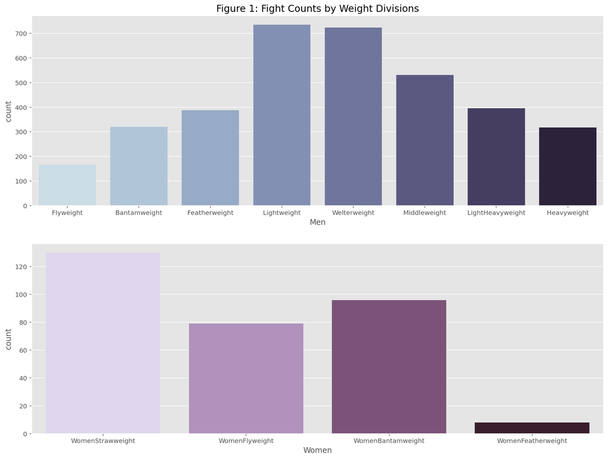

```python
plt.figure(figsize = (16,12))


plt.subplot(2, 1, 1)
sns.countplot(x = 'weight_class', data = df, palette = 'ch:s=.25, rot=-.25',
                   order = ['Flyweight', 'Bantamweight', 'Featherweight', 'Lightweight', 'Welterweight', 'Middleweight', 'LightHeavyweight', 'Heavyweight'])
plt.xlabel("Men")
plt.title('Figure 1: Fight Counts by Weight Divisions', fontsize=15)


plt.subplot(2, 1, 2)
sns.countplot(x = 'weight_class', data = df, palette = 'ch:s=.75, rot=-.25',
                   order = ['WomenStrawweight', 'WomenFlyweight', 'WomenBantamweight', 'WomenFeatherweight'])
plt.xlabel('Women')


plt.show()
```

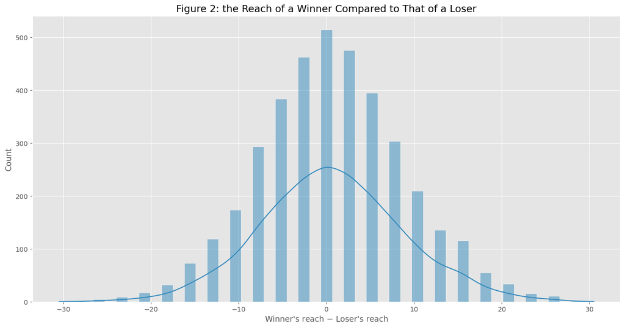

```python
df_copy = df.copy()
df_copy = df_copy[(df_copy['winner'] == 'Red') | (df_copy['winner'] == 'Blue')]
df_copy.reset_index(drop=True, inplace=True)

num_winners = df_copy.shape[0]
# Create an ndarray to store the differences between the reaches of winners and losers
np_reach_diff = np.empty(num_winners)

for index, row in df_copy.iterrows():
    if row['winner'] == 'Red':
        np_reach_diff[index] = row['r_reach_cms'] - row['b_reach_cms']
    elif row['winner'] == 'Blue':
        np_reach_diff[index] = row['b_reach_cms'] - row['r_reach_cms']

plt.figure(figsize= (16,8))
sns.histplot(np_reach_diff, kde=True).set_title('Figure 2: the Reach of a Winner Compared to That of a Loser', fontsize = 15)

plt.xlabel("Winner's reach $-$ Loser's reach")
plt.show()
```

As we can see above, a small difference in lengths of arms does not seem to play a significant role in the sport. There are slightly more win counts for those with a longer reach than those with a proportionally shorter reach.

### Bivariate Visualisation

We shall now investigate what attributes correlate with fighters on a winning streak. We will assemble an ad hoc dataset on fighters currently (21/03/2021) on a winning streak for more than 2 consecutive fights.

```python
r_column_names = df.columns[df.columns.str.startswith('r_')].tolist() + ['weight_class']
r_winners = df.loc[df['winner'] == 'Red', r_column_names]
r_winners.reset_index(level=1, drop=True, inplace=True)
r_winners.reset_index(level=0, inplace=True)
r_winners.rename(columns={name : name[2:] for name in r_column_names if name.startswith('r_')}, inplace=True)
r_winners.rename(columns={'r_fighter':'fighter'}, inplace=True)

b_column_names = df.columns[df.columns.str.startswith('b_')].tolist() + ['weight_class']
b_winners = df.loc[df['winner'] == 'Blue', b_column_names]
b_winners.reset_index(level=0, drop=True, inplace=True)
b_winners.reset_index(level=0, inplace=True)
b_winners.rename(columns={name : name[2:] for name in b_column_names if name.startswith('b_')}, inplace=True)
b_winners.rename(columns={'b_fighter':'fighter'}, inplace=True)

winners = pd.concat([r_winners, b_winners]).sort_index(kind='merge')
winners = winners.set_index('fighter')
winners = winners[~winners.index.duplicated(keep='first')]
winners_win_streak = winners[(winners['post_fight_win_streak'] > 2)]
```

#### Boxplot of Winning Streaks by Stances

Let us first find out the distribution of stances among winners on a winning streak for more than 2 fights categorized by weight classes.

```python
import altair as alt
alt.renderers.enable('default')

alt.Chart(winners_win_streak,
          width = 500,
          title = 'Winners by Weight Class and Stance'
         ).mark_bar(opacity = 0.9
         ).encode(x=alt.X('weight_class',
                        title='Weight Class',
                        sort=['Flyweight', 'Bantamweight', 'Featherweight', 'Lightweight', 'Welterweight', 'Middleweight', 'LightHeavyweight', 'Heavyweight', 'CatchWeight', 'WomenStrawweight', 'WomenFlyweight', 'WomenBantamweight', 'WomenFeatherweight'],
                        axis=alt.AxisConfig(labelAngle=45)),
                  y=alt.Y('count()', title = 'Number of Winning Fighters'),
                  color='stance')
```

[interactive chart not shown]

From Figure 3 below, we can see that the median number of consecutive wins for both orthodox and southpaw fighters on a longer-than-2 winning streak is 3. The orthodox stance has many outliers on a longer winning streak. This, however, can be due to a larger number of orthodox fighters in the population compared to fighters with other stances.

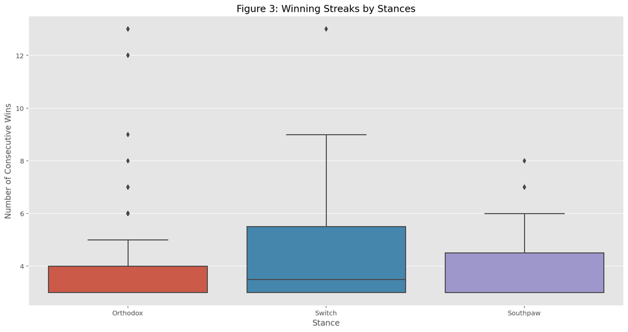

```python
plt.figure(figsize=(16,8))
sns.boxplot(winners_win_streak['stance'], winners_win_streak['post_fight_win_streak'])
plt.title('Figure 3: Winning Streaks by Stances')
plt.xlabel('Stance')
plt.ylabel('Number of Consecutive Wins')
plt.show()
```

#### Regplot of Significant Strikes Landed and Attempts of Different Types

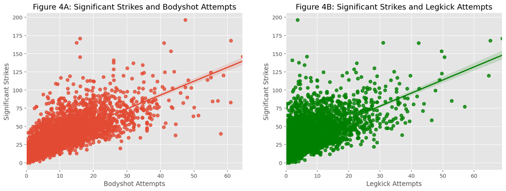

```python
avg_sig_str_landed = pd.concat([df.loc[df['winner'] == 'Red', 'r_avg_sig_str_landed'], df.loc[df['winner'] == 'Blue', 'b_avg_sig_str_landed']])
avg_body_att = pd.concat([df.loc[df['winner'] == 'Red', 'r_avg_body_att'], df.loc[df['winner'] == 'Blue', 'b_avg_body_att']])
avg_leg_att = pd.concat([df.loc[df['winner'] == 'Red', 'r_avg_leg_att'], df.loc[df['winner'] == 'Blue', 'b_avg_leg_att']])

plt.figure(figsize=(16,12))
plt.subplot(2,2,1)
sns.regplot(avg_body_att, avg_sig_str_landed)
plt.title('Figure 4A: Significant Strikes and Bodyshot Attempts')
plt.xlabel('Bodyshot Attempts')
plt.ylabel('Significant Strikes')

plt.subplot(2,2,2)
sns.regplot(avg_leg_att, avg_sig_str_landed, color='g')
plt.title('Figure 4B: Significant Strikes and Legkick Attempts')
plt.xlabel('Legkick Attempts')
plt.ylabel('Significant Strikes')

plt.show()
```

### Three-Variable Visualisation

#### Barplot of Average Headshots Landed on Losing Fighters by Opponents Juxtaposed with Age and Weight Class

We now select fighters on a losing streak for 2 or more consecutive fights and see what jumps out in the visualized data. Prior to their most recently defeated fight, they have taken an average of 25 shot to the head per fight. In contrast to these fighters, fighters on a winning streak take 16 shots to the head on average per fight.

Women's weight divisions have more marked variability in the average number of landed headshots, indicating greater variability in technique compared to the men's.

We also see that regardless of whether fighters have been winning or losing, the older they are, the more shots to the head on average they receive, more often than not.

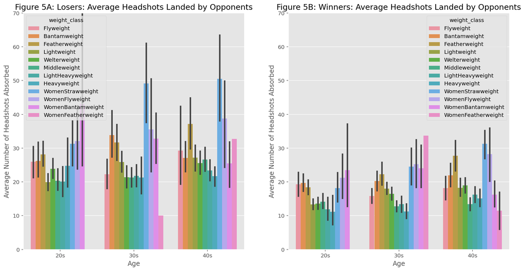

```python
losing_b_fighters = df.loc[df['b_post_fight_lose_streak'] > 1, ['b_avg_opp_head_landed', 'b_age', 'weight_class']]
winning_b_fighters = df.loc[df['b_post_fight_win_streak'] > 1, ['b_avg_opp_head_landed', 'b_age', 'weight_class']]
losing_r_fighters = df.loc[df['r_post_fight_lose_streak'] > 1, ['r_avg_opp_head_landed', 'r_age', 'weight_class']]
winning_r_fighters = df.loc[df['r_post_fight_win_streak'] > 1, ['r_avg_opp_head_landed', 'r_age', 'weight_class']]

losing_b_fighters.reset_index(level=0, drop=True, inplace=True)
winning_b_fighters.reset_index(level=0, drop=True, inplace=True)
losing_b_fighters.rename(columns={'b_avg_opp_head_landed': 'avg_opp_head_landed', 'b_age':'age'},inplace=True)
winning_b_fighters.rename(columns={'b_avg_opp_head_landed': 'avg_opp_head_landed', 'b_age':'age'},inplace=True)
losing_b_fighters.index.name = 'fighter'
winning_b_fighters.index.name = 'fighter'

losing_r_fighters.reset_index(level=1, drop=True, inplace=True)
winning_r_fighters.reset_index(level=1, drop=True, inplace=True)
losing_r_fighters.rename(columns={'r_avg_opp_head_landed': 'avg_opp_head_landed', 'r_age':'age'},inplace=True)
winning_r_fighters.rename(columns={'r_avg_opp_head_landed': 'avg_opp_head_landed', 'r_age':'age'},inplace=True)
losing_r_fighters.index.name = 'fighter'
winning_r_fighters.index.name = 'fighter'

losing_fighters = pd.concat([losing_b_fighters, losing_r_fighters])
winning_fighters = pd.concat([winning_b_fighters, winning_r_fighters])
losing_fighters = losing_fighters[(losing_fighters['age'] >= 20) & (losing_fighters['age'] <= 50)]
winning_fighters = winning_fighters[(winning_fighters['age'] >= 20) & (winning_fighters['age'] <= 50)]
losing_fighters['age'] = pd.qcut(losing_fighters['age'], 3, labels=['20s', '30s', '40s'])
winning_fighters['age'] = pd.qcut(winning_fighters['age'], 3, labels=['20s', '30s', '40s'])

plt.figure(figsize=(16,8))
plt.subplot(1, 2, 1)
ax = sns.barplot(data=losing_fighters, x='age', y='avg_opp_head_landed', hue='weight_class', hue_order=['Flyweight', 'Bantamweight', 'Featherweight', 'Lightweight', 'Welterweight', 'Middleweight', 'LightHeavyweight', 'Heavyweight', 'WomenStrawweight', 'WomenFlyweight', 'WomenBantamweight', 'WomenFeatherweight'])
ax.set(xlabel='Age', ylabel='Average Number of Headshots Absorbed')
plt.ylim(0, 70)
plt.title('Figure 5A: Losers: Average Headshots Landed by Opponents')

plt.subplot(1, 2, 2)
ax = sns.barplot(data=winning_fighters, x='age', y='avg_opp_head_landed', hue='weight_class', hue_order=['Flyweight', 'Bantamweight', 'Featherweight', 'Lightweight', 'Welterweight', 'Middleweight', 'LightHeavyweight', 'Heavyweight', 'WomenStrawweight', 'WomenFlyweight', 'WomenBantamweight', 'WomenFeatherweight'])
ax.set(xlabel='Age', ylabel='Average Number of Headshots Absorbed')
plt.ylim(0, 70)
plt.title('Figure 5B: Winners: Average Headshots Landed by Opponents')

plt.show()
```

#### Boxplot of Average Takedown Success Rate by Stance and Weight Divisions

Figure 6A shows that fighters in this category finish their opponents early half the time before "going the distance". Grappling submission makes up a large portion of their finishing repertoire.

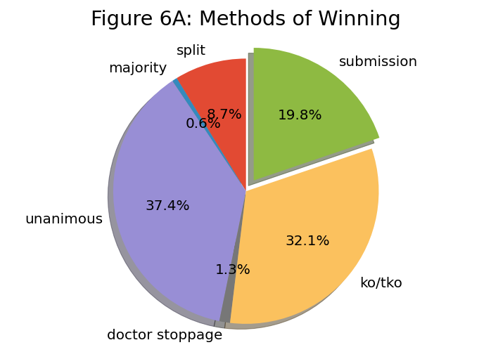

```python
labels = 'split', 'majority', 'unanimous', 'doctor stoppage', 'ko/tko', 'submission'
sizes = [winners_win_streak['win_by_decision_split'].sum(), winners_win_streak['win_by_decision_majority'].sum(), winners_win_streak['win_by_decision_unanimous'].sum(), winners_win_streak['win_by_tko_doctor_stoppage'].sum(), winners_win_streak['win_by_ko_tko'].sum(), winners_win_streak['win_by_submission'].sum()]
explode = (0, 0, 0, 0, 0, 0.1)  # only "explode" the 2nd slice (i.e. 'Hogs')

fig1, ax1 = plt.subplots()
plt.title('Figure 6A: Methods of Winning')
ax1.pie(sizes, explode=explode, labels=labels, autopct='%1.1f%%',
        shadow=True, startangle=90)
ax1.axis('equal')  # Equal aspect ratio ensures that pie is drawn as a circle.

plt.show()
```

Now that we know submission is an indispensable skill to help fighters win, we go ahead and look at the average takedown-success percentage by stance and weight class. Figure 6B shows the light heavyweight division lacks fighters with high success rates of takedown.

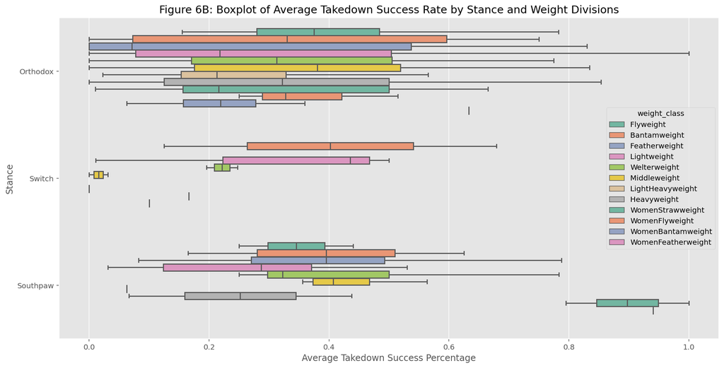

```python
plt.figure(figsize=(16,8))
plt.title('Figure 6B: Boxplot of Average Takedown Success Rate by Stance and Weight Divisions')

ax = sns.boxplot(winners_win_streak['avg_td_pct'], winners_win_streak['stance'],
            palette='Set2', hue = winners_win_streak['weight_class'], hue_order=['Flyweight', 'Bantamweight', 'Featherweight', 'Lightweight', 'Welterweight', 'Middleweight', 'LightHeavyweight', 'Heavyweight', 'WomenStrawweight', 'WomenFlyweight', 'WomenBantamweight', 'WomenFeatherweight'])
ax.set(xlabel="Average Takedown Success Percentage", ylabel='Stance')
plt.show()
```

## Summary and Conclusion

Our raw dataset was by no means perfect as it came with a few logical slips that needed correction, after which we were confident in the integrity of our derived response feature `R_post_fight_win_streak`. We have dropped the features whose values definitely do not contribute to the better fit of our predictive model. For Phase 2, we have renamed the columns as required and created another version of the dataset that contains no outliers.

Through visualisation of our dataset, we now understand a merit of weight cutting, especially for those whose walking around weights indicate they belong to the lightweight division, but they trim down a great deal to the featherweight to gain a weight advantage. As fight counts in each division are indicative of its total population, there is a higher probability that the lightweight and welterweight divisions will house a larger number of highly technical fighters. For that reason, lightweight fighters who think like statisticians might want to consider competing at the featherweight class. However, those who weigh between the welterweight and middleweight divisions may want to skimp on weight-cutting and try the heavier division should they have an unsuccessful run in the lighter division.

We intuitively understand fighters with a longer reach are at an advantage. Data have shown slightly higher win counts for slightly lengthier fighters. However, the difference in counts gets rather significant when there is 10 centimeters or more difference in the reach.

Fighters on a losing streak are characterized by a cumulative average of 20 or more shots to the head in all their previous fights. In comparison to them, fighters on a winning streak tend to absorb fewer headshots. Fighters might benefit from practicing parrying, ducking and sliding away punches aimed at their heads followed by their own share of punches to the opponent's head to increase their chances of winning. We also have seen that age has a positive association with the number of head shots absorbed in most weight divisions. For fighters who want to retire as unscathed as they once cut their teeth, it may be wise to get in early and leave the sport as early.

We also see that grappling submission is a highly favored way for fighters on a winning streak to finish their opponents. In weight divisions where the average takedown percentage is high, fighters might thrive by honing their responsive submission skills to cancel out the effectiveness of a takedown. In weight divisions where the average takedown percentage is low, fighters could improve their takedown skills to take advantage of other fighters who are used to standing up and hence, perhaps, less skilled in defending takedowns.

The dataset has far too many descriptive features to find all the meaningful correlations with the response feature through plotting only. We will undertake such a mission in Phase 2 through multiple regression. Should its model fit turn out to be not as promising as we now hope, we shall try NN models to predict post-fight winning streaks of fighters.

```python
# Drop the columns as planned for Phase 2
df.drop(columns=['winner', 'b_post_fight_win_streak', 'r_post_fight_lose_streak', 'b_post_fight_lose_streak'], inplace=True)
df_without_outliers.drop(columns=['winner', 'b_post_fight_win_streak', 'r_post_fight_lose_streak', 'b_post_fight_lose_streak'], inplace=True)
```

## References

- Warrier, R. (2019). UFC-Fight historical data from 1993 to 2021 (Kaggle). Retrieved September 30, 2021 from https://www.kaggle.com/rajeevw/ufcdata
- DraftKings (n.d.). MMA Classic. Retrieved October 3, 2021 from https://au.draftkings.com/help/rules/9